# Superenhancer analysis

Kate Lawrenson, Marcos A. S. Fonseca, Annie Y. Liu, Felipe Segato, et. al.

November, 2019

## Introduction

In the following workflow, we describe the main procedures to analyse the gene expression profile of associated genes to superenghancers (SE) genomic regions.

```r
library(TxDb.Hsapiens.UCSC.hg19.knownGene)
library(org.Hs.eg.db)
library(GenomicRanges)
```

### Auxiliary functions

Obtaining only distinct peaks from a given `Genomic Ranges` Object

```r
distinctGR <- function(objectGR) {
  adj_hgsonc_union = objectGR

  index = 1
  final = length(adj_hgsonc_union)

  distinct_table = NULL

  while (index <= final) {

    res = as.data.frame(findOverlaps(adj_hgsonc_union[index], adj_hgsonc_union))
    n = dim(res)[1]

    if (n > 1) {
      adj_hgsonc_union = adj_hgsonc_union[-res$subjectHits[2:n]]
    }

    distinct_table = rbind(distinct_table, as.data.frame(adj_hgsonc_union[res$subjectHits[1]]))

    index = index + 1
    final = length(adj_hgsonc_union)
  }

  return(distinct_table)

}
```

Obtaining only distinct peaks by comparing two `Genomic Ranges` objects

```r
distinctGRPairs <- function(query, subject) {
  index = 1
  final = length(query)

  distinct_table = NULL

  while (index <= final) {

    res = as.data.frame(findOverlaps(query[index], subject))
    n = dim(res)[1]

    if (n < 1) {
      distinct_table = rbind(distinct_table, as.data.frame(query[index]))
    }

    index = index + 1
  }

  return(distinct_table)

}
```

### Part 1

### Data loading

```r
load("RData/190Normal-394TCGA-combatGCnorm_all_data.rda")
```

|  | 176-p6 | 179-Lp6 | 181-Lp7 | 185-p5 | 189-Lp6 | 191-Lp5 | 192-Rp4 | 197-Lp6 | 1mR-p4 | 200-p6 |
| --- | --- | --- | --- | --- | --- | --- | --- | --- | --- | --- |
| WASH7P | 4.466708 | 3.854710 | -1.635562 | -1.635562 | -1.635562 | -1.635562 | -1.635562 | -1.635562 | -1.635562 | -1.635562 |
| OR4F5 | -5.317438 | -5.317438 | -5.317438 | -5.317438 | -5.317438 | -5.317438 | -5.317438 | -5.317438 | -5.317438 | -5.317438 |
| OR4F29 | -5.276078 | -5.276078 | -5.276078 | -5.276078 | -5.276078 | -5.276078 | -5.276078 | -5.276078 | -5.276078 | -5.276078 |
| OR4F16 | -5.308478 | -5.308478 | -5.308478 | -5.308478 | -5.308478 | -5.308478 | -5.308478 | -5.308478 | -5.308478 | -5.308478 |
| LINC00115 | -3.934121 | 3.119557 | 1.581284 | -3.934121 | -3.934121 | 4.701893 | 2.901779 | 2.330278 | 2.346626 | 1.414174 |

```r
load("RData/NormalsSamplesTableV3.RData")
head(NormalSamplesTable)
```

```
##   Samples CellType  Colors SP Batch
## 1  176_p6     NOSE #377EB8 NO    B1
## 2 179_Lp6     NOSE #377EB8 NO    B1
## 3 181_Lp7     NOSE #377EB8 NO    B1
## 4  185_p5     NOSE #377EB8 NO    B1
## 5 189_Lp6     NOSE #377EB8 NO    B1
## 6 191_Lp5     NOSE #377EB8 NO    B1
```

```r
nTCGAsamples = 394

TCGAsamplesTable = data.frame(Samples = colnames(dados.RNAseq)[191:584], CellType = c(rep("HGSOC", nTCGAsamples)), Colors=c(rep("green", nTCGAsamples)), SP="None", Batch="None" )

SamplesTable = rbind(NormalSamplesTable, TCGAsamplesTable)
```

### Gene genomic annotation

We selected the genomic annotation, regarding chromosome name, start, end coordinates for human hg19 build. After the annation is merged with our expressed genes.

```r
dados.RNAseq <- as.data.frame(dados.RNAseq)

txdb_hg19 <- TxDb.Hsapiens.UCSC.hg19.knownGene
genes <- genes(txdb_hg19)
symbols <- unlist(mapIds(org.Hs.eg.db, genes$gene_id, "SYMBOL", "ENTREZID", multiVals = "first"))
genes <- as.data.frame(genes)
genes$symbol <- as.matrix(symbols)
genes <- genes[!(duplicated(genes$symbol)),]
head(genes)

dados.RNAseq <- merge(genes,dados.RNAseq, by.x="symbol",by.y="row.names")
```

Convert gene annotation into a Genomic Ranges object `dados.RNAseq.GR`. The merged data.frame also is splited into annotation `dados.RNAseq.DF` and expression information `dados.RNAseq.f`. After, the expression values are scaled as follows.

```r
dados.RNAseq.GR <- makeGRangesFromDataFrame(dados.RNAseq[,1:7],TRUE)
dados.RNAseq.DF <- dados.RNAseq[,1:7]
dados.RNAseq.f <- dados.RNAseq[,c(8:591)]

dados.RNAseq.scaled <- t(scale(t(dados.RNAseq.f)))
rownames(dados.RNAseq.scaled) <- dados.RNAseq.DF$symbol
```

### Superenhancer experiments

In this step we will processing the superenhancer bed files. First, the data is loaded and converted to Genomic Ranges Object. The experiments are combined in a single object. Then, using the aulixiliary function `distinctGR`, we selected only those regions that are unique considering the entire combined set. The same procedures are applied to OSEC, FTSEC and HGSOC superenhancers.

```r
########### OSEC #################
ose4 = read.table("se/IOSE4_ResultCount_C30H4ACXX_1_SHE1405A185.male.hg19.fa.nodup.superEnhancers.bed")
colnames(ose4) = c("chrom", "start", "end", "name", "score", "strand")
ose4 = makeGRangesFromDataFrame(ose4)

ose11 = read.table("se/IOSE11_ResultCount_D1AHBACXX_8_SHE1405A43.male.hg19.fa.nodup.superEnhancers.bed")
colnames(ose11) = c("chrom", "start", "end", "name", "score", "strand")
ose11 = makeGRangesFromDataFrame(ose11)

ose4.df <- as.data.frame(ose4)
ose11.df <- as.data.frame(ose11)

nose_total <- rbind(ose4.df, ose11.df)
nose_total <- makeGRangesFromDataFrame(nose_total)

distinct_table = distinctGR(nose_total)
nose_union = makeGRangesFromDataFrame(distinct_table)

########### FTSEC #################

ft33 = read.table("se/FT33_ResultCount_C26CUACXX_2_SHE1405A78.male.hg19.fa.nodup.superEnhancers.bed")
colnames(ft33) = c("chrom", "start", "end", "name", "score", "strand")
ft33 = makeGRangesFromDataFrame(ft33)

ft246 = read.table("se/FT246_ResultCount_C269LACXX_5_SHE1405A86.male.hg19.fa.nodup.superEnhancers.bed")
colnames(ft246)  = c("chrom", "start", "end", "name", "score", "strand")
ft246 = makeGRangesFromDataFrame(ft246)

ft33.df <- as.data.frame(ft33)
ft246.df <- as.data.frame(ft246)

nfte_total = rbind(ft33.df, ft246.df)
nfte_total = makeGRangesFromDataFrame(nfte_total)

distinct_table = distinctGR(nfte_total)
nfte_union = makeGRangesFromDataFrame(distinct_table)

########### HGSOC #################

hgs229 = read.table("se/HGSerous_229_IP.nodup.superEnhancers.bed")
colnames(hgs229) = c("chrom", "start", "end", "name", "score", "strand")
hgs229 = makeGRangesFromDataFrame(hgs229)

hgs429 = read.table("se/HGSerous_429_IP.nodup.superEnhancers.bed")
colnames(hgs429) = c("chrom", "start", "end", "name", "score", "strand")
hgs429 = makeGRangesFromDataFrame(hgs429)

hgs561 = read.table("se/HGSerous_561_IP.nodup.superEnhancers.bed")
colnames(hgs561) = c("chrom", "start", "end", "name", "score", "strand")
hgs561 = makeGRangesFromDataFrame(hgs561)

hgs550 = read.table("se/HG_Serous_550_IP.nodup.superEnhancers.bed")
colnames(hgs550) = c("chrom", "start", "end", "name", "score", "strand")
hgs550 = makeGRangesFromDataFrame(hgs550)

hgs270 = read.table("se/HGSerous_270_IP.nodup.superEnhancers.bed")
colnames(hgs270) = c("chrom", "start", "end", "name", "score", "strand")
hgs270 = makeGRangesFromDataFrame(hgs270)

hgs229.df <- as.data.frame(hgs229)
hgs429.df <- as.data.frame(hgs429)
hgs561.df <- as.data.frame(hgs561)
hgs550.df <- as.data.frame(hgs550)
hgs270.df <- as.data.frame(hgs270)

hgsoc_total <- rbind(hgs229.df, hgs429.df, hgs561.df, hgs550.df, hgs270.df)
hgsoc_total = makeGRangesFromDataFrame(hgsoc_total)

distinct_table = distinctGR(hgsoc_total)
hgsoc_union = makeGRangesFromDataFrame(distinct_table)
```

In this step the SE are cross compared in order to obtain only distict ones per cell type. The auxiliary function `distinctGRPairs` is used.

```r
subj = makeGRangesFromDataFrame(rbind(as.data.frame(hgsoc_union), as.data.frame(nfte_union)))
tempN = distinctGRPairs(nose_union, subj)
nose_distinct = makeGRangesFromDataFrame(tempN)

subj = makeGRangesFromDataFrame(rbind(as.data.frame(hgsoc_union), as.data.frame(nose_union)))
tempF = distinctGRPairs(nfte_union, subj)
nfte_distinct = makeGRangesFromDataFrame(tempF)

subj = makeGRangesFromDataFrame(rbind(as.data.frame(nose_union), as.data.frame(nfte_union)))
tempR = distinctGRPairs(hgsoc_union, subj)
hgsoc_distinct = makeGRangesFromDataFrame(tempR)
```

### Preparing the parameters

Identify expression profile considering all samples into 3 groups: OSEC - 119 samples FTSEC - 71 samples HGSOC - 394 samples

We also defined a step size of 5000 bp and a window size of 1000000 bp.

```r
OSECLines <- which(SamplesTable$CellType == "NOSE")
FTSECLines <- which(SamplesTable$CellType == "NFTE")
HGSOCLines <- which(SamplesTable$CellType == "HGSOC")

step = 5000
window = 1000000
range.neigh = seq(-window, window, step)
```

### Part 2

Obtaining the gene expression profile across the 3 cell types considering OSEC specific enhancers.

```r
enhancer = nose_distinct
enh_name = "OSEC_enh_"
names <- paste0("OSEC_enh_", seq(1, length(enhancer)))
```

### Part 3

Now we can begin to find the genes and their correspondent expression in all 3 cell types with the following iteraction loop.

```r
#####################

e.index = 1
genes.range.all = NULL

while (e.index <= length(enhancer)) {
  #print(paste0("Enhancer ", e.index))

  e.info = enhancer[e.index]

  mid.pos = round(start(e.info) + ((end(e.info) - start(e.info)) / 2))
  s.pos = mid.pos - window
  e.pos = mid.pos + window
  chr.pos = as.character(seqnames(e.info))
  new.genes.range = seq(s.pos, e.pos, step)

  new.enh.range.GR = GRanges(seqnames=chr.pos, ranges=IRanges(s.pos, e.pos))

  res = findOverlaps(new.enh.range.GR, dados.RNAseq.GR, type = "any", select = "all", ignore.strand=TRUE)

  if (length(res) > 0) {

    genes.range = dados.RNAseq.DF[subjectHits(res),]

    OSEC.mean =  apply(dados.RNAseq.f[subjectHits(res),OSECLines],1,mean,na.rm=T)
    FTSEC.mean =  apply(dados.RNAseq.f[subjectHits(res),FTSECLines],1,mean,na.rm=T)
    HGSOC.mean =  apply(dados.RNAseq.f[subjectHits(res),HGSOCLines],1,mean,na.rm=T)

    genes.range = cbind(Enh = paste0(enh_name, e.index), genes.range, Mean.OSEC=OSEC.mean, Mean.FTSEC=FTSEC.mean, Mean.HGSOC=HGSOC.mean)

    for (gi in 1:nrow(genes.range)) {

      gene = genes.range[gi,]
      index = 1

      for (value in new.genes.range) {

        if (value > gene$start) {
          break
        }
        index = index + 1
      }

      genes.range$pos[gi] = range.neigh[index]

    } # end for

    genes.range.all = rbind(genes.range.all, genes.range)

  }

  e.index = e.index + 1
}

#################
```

## Part 4

Calculate the z-score for each cell type gene list.

```r
info.plot.nose = data.frame(Position = range.neigh, Type = "OSEC", Value=NA)
info.plot.ftsec = data.frame(Position = range.neigh, Type = "FTSEC", Value=NA)
info.plot.hgsoc = data.frame(Position = range.neigh, Type = "HGSOC", Value=NA)

index.pos = 1
for ( pos in range.neigh ) {

  if (pos < 0) {
    sub.range = seq(pos, 0, step)

  } else if (pos > 0) {
    sub.range = seq(0, pos, step)
  }

  rows.m <- which(genes.range.all$pos %in% sub.range)
  enh.name <- unique(genes.range.all$Enh[rows.m])
  enh.index <- which(names %in% enh.name)
  genes.name = unique(genes.range.all$symbol[rows.m])

  info.plot.nose$Value[index.pos] <- mean(dados.RNAseq.scaled[genes.name, OSECLines])
  info.plot.ftsec$Value[index.pos] <- mean(dados.RNAseq.scaled[genes.name, FTSECLines])
  info.plot.hgsoc$Value[index.pos] <- mean(dados.RNAseq.scaled[genes.name, HGSOCLines])

  index.pos = index.pos + 1
}

##########################
```

Plotting the final result

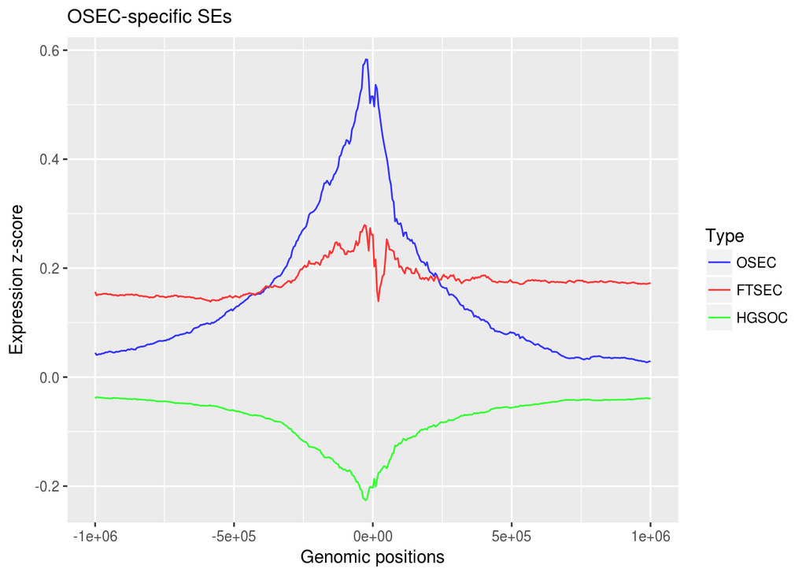

```r
nose.info.plot.all = rbind(info.plot.nose, info.plot.ftsec, info.plot.hgsoc)

p_osec = ggplot(data=nose.info.plot.all, aes(x=Position, y=Value, colour = Type)) +
  labs(title = paste0("OSEC-specific SEs"), y = "Expression z-score", x = "Genomic positions") +
  theme(plot.title = element_text(size=12)) +
  scale_color_manual(values=c("#3333ffff", "#ff3333ff", "#33ff33ff" )) +
  geom_line()
p_osec
```

### Conclusion

We demonstrated how to obtain the expression profile of genes associated to SE genomic regions. The same procedures can be now applied to FTSEC and HGSOC specific SE by changuing Part 2 and running again Part 3 and 4.